# **QUICK SORT**

## **Combine**

Tahap kedua pada algoritma quicsort adalah tahapan combine. Pada tahapan ini, hanya memerintahkan partisi yang berulang kali. Data yang sudah dipartisi, akan terdiri dari dua bagian data, yaitu bagian pertama dan kedua. Bagian pertama dilakukan partisi lagi, menjadi dua buah bagian, begitu juga bagian kedua, begitu seterusnya, sampai tidak ada data lagi yang akan dipartisi. Sehingga hasil akhir adalah, data akan terurut.

Proses combine yang dilakukan dengan cara memerintahkan partisi berulang, seperti yang terlihat pada Gambar 3.

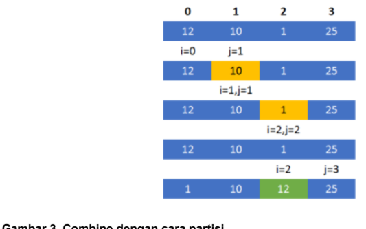

Gambar 3 tersebut menunjukkan partisi kembali data-data sebelum nilai pivot = 37. Proses partisi yang kedua ini menghasilkan nilai pivot baru yaitu 12, dimana data ini berada pada indeks ke-2. Akhir dari kedua partisi yang telah dilakukan, dimana telah dihasilkan nilai pivot 37 dengan indeks ke-4, serta nilai pivot 12 dengan indeks ke-2, menunjukkan bahwa, ketika data terurut, nilai 37 dan nilai 12 memang menempati posisi indeks ke-4 dan ke-2, seperti yang ditunjukkan pada Gambar 4.

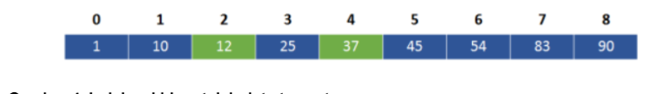

```python
# Code
# Berikut adalah fungsi combine untuk algoritma quicksort

def Quicksort(A,p,q):
    if p<q:
        r=partition(A,p,q)
        Quicksort(A, p, r-1)
        Quicksort(A, r+1, q)
```

```python
a=[37,83,10,1,45,25,12,90,54]
Quicksort(a,0,len(a)-1)
```

[output not shown]

Sesuai namanya, Quicksort adalah salah satu algoritma pengurutan tercepat.

Algoritma Quicksort mengambil sebuah array nilai, memilih salah satu nilai sebagai elemen 'pivot', dan memindahkan nilai-nilai lainnya sehingga nilai yang lebih rendah berada di sebelah kiri elemen pivot, dan nilai yang lebih tinggi berada di sebelah kanannya.

Dalam tutorial ini, elemen terakhir dari array dipilih sebagai elemen pivot, tetapi kita juga bisa memilih elemen pertama dari array, atau elemen apa pun dalam array.

Kemudian, algoritma Quicksort melakukan operasi yang sama secara rekursif pada sub-array di sisi kiri dan kanan elemen pivot. Proses ini berlanjut hingga array terurut.

**Rekursi** terjadi ketika sebuah fungsi memanggil dirinya sendiri.

Setelah algoritma Quicksort menempatkan elemen pivot di antara sub-array dengan nilai lebih rendah di sisi kiri, dan sub-array dengan nilai lebih tinggi di sisi kanan, algoritma tersebut memanggil dirinya sendiri dua kali, sehingga Quicksort berjalan lagi untuk sub-array di sisi kiri, dan untuk sub-array di sisi kanan. Algoritma Quicksort terus memanggil dirinya sendiri hingga sub-array terlalu kecil untuk diurutkan.

Algoritma tersebut dapat dijelaskan seperti ini:

**Cara kerjanya:**

Pilih sebuah nilai dalam larik untuk menjadi elemen poros. Susun elemen-elemen array lainnya sehingga nilai yang lebih rendah dari elemen pivot berada di sebelah kiri, dan nilai yang lebih tinggi berada di sebelah kanan. Tukarkan elemen pivot dengan elemen pertama dari nilai yang lebih tinggi sehingga elemen pivot berada di antara nilai yang lebih rendah dan nilai yang lebih tinggi. Lakukan operasi yang sama (secara rekursif) untuk sub-array di sisi kiri dan kanan elemen pivot.

## Panduan Langkah demi Langkah

Sebelum kita mengimplementasikan algoritma Quicksort dalam bahasa pemrograman, mari kita jalankan secara manual sebuah array pendek, hanya untuk mendapatkan gambaran umumnya.

**Langkah 1:** Kita mulai dengan array yang belum diurutkan.

[ 11, 9, 12, 7, 3]

**Langkah 2:** Kita memilih nilai terakhir yaitu 3 sebagai elemen pivot.

[ 11, 9, 12, 7, 3]

**Langkah 3:** Nilai-nilai lainnya dalam array semuanya lebih besar dari 3, dan harus berada di sebelah kanan 3. Tukar 3 dengan 11.

[ 3, 9, 12, 7, 11]

**Langkah 4:** Nilai 3 sekarang berada di posisi yang benar. Kita perlu mengurutkan nilai-nilai di sebelah kanan 3. Kita memilih nilai terakhir, yaitu 11, sebagai elemen pivot yang baru.

[ 3, 9, 12, 7, 11] **Langkah 5:** Nilai 7 harus berada di sebelah kiri nilai pivot 11, dan 12 harus berada di sebelah kanannya. Pindahkan 7 dan 12.

[ 3, 9, 7, 12, 11] **Langkah 6:** Tukar angka 11 dengan 12 sehingga nilai yang lebih rendah yaitu 9 dan 7 berada di sisi kiri angka 11, dan angka 12 berada di sisi kanan.

[ 3, 9, 7, 11, 12]

**Langkah 7:** 11 dan 12 berada pada posisi yang benar. Kita memilih 7 sebagai elemen pivot dalam sub-array [ 9, 7], di sebelah kiri 11.

[ 3, 9, 7, 11, 12]

**Langkah 8:** Kita harus menukar angka 9 dengan angka 7.

[ 3, 7, 9, 11, 12] Dan sekarang, array tersebut sudah diurutkan.

## Mengimplementasikan Quicksort di Python

Untuk menulis metode 'quickSort' yang membagi array menjadi sub-array yang semakin pendek, kita menggunakan rekursi. Ini berarti bahwa metode 'quickSort' harus memanggil dirinya sendiri dengan sub-array baru di sebelah kiri dan kanan elemen pivot. Baca selengkapnya tentang rekursi di sini .

Untuk mengimplementasikan algoritma Quicksort dalam program Python, kita membutuhkan:

1. Sebuah array berisi nilai-nilai yang akan diurutkan.
2. Metode quickSort yang memanggil dirinya sendiri (rekursi) jika sub-array memiliki ukuran lebih besar dari 1.
3. Metode partisi yang menerima sub-array, memindahkan nilai-nilai di dalamnya, menukar elemen pivot ke dalam sub-array, dan mengembalikan indeks tempat pemisahan sub-array berikutnya terjadi.

Kode yang dihasilkan akan terlihat seperti ini:

```python
# ContohDapatkan server Python Anda sendiri
# Menggunakan algoritma Quicksort dalam program Python:

def partition(array, low, high):
  pivot = array[high]
  i = low - 1

  for j in range(low, high):
     if array[j] <= pivot:
       i += 1
       array[i], array[j] = array[j], array[i]

  array[i+1], array[high] = array[high], array[i+1]
  return i+1

def quicksort(array, low=0, high=None):
  if high is None:
    high = len(array) - 1

  if low < high:
    pivot_index = partition(array, low, high)
    quicksort(array, low, pivot_index-1)
    quicksort(array, pivot_index+1, high)

mylist = [64, 34, 25, 5, 22, 11, 90, 12]
quicksort(mylist)
print(mylist)
```

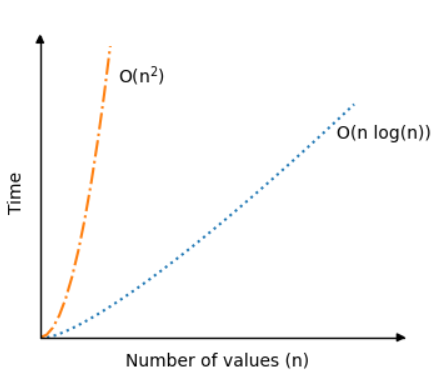

Bagian rekursi dari algoritma Quicksort sebenarnya adalah alasan mengapa skenario pengurutan rata-rata sangat cepat, karena untuk pemilihan elemen pivot yang baik, array akan dibagi menjadi dua secara merata setiap kali algoritma memanggil dirinya sendiri. Jadi jumlah panggilan rekursif tidak berlipat ganda, meskipun jumlah nilai N dobel.

**QuickSort** adalah algoritma pengurutan berdasarkan prinsip Bagi dan Taklukkan yang memilih sebuah elemen sebagai pivot dan mempartisi array yang diberikan di sekitar pivot yang dipilih dengan menempatkan pivot pada posisi yang benar dalam array yang telah diurutkan.

1. Pilih Pivot: Pilih salah satu elemen dari array sebagai pivot. Pilihan pivot dapat bervariasi (misalnya, elemen pertama, elemen terakhir, elemen acak, atau median).
2. Mempartisi Larik: Susun ulang larik di sekitar elemen pivot. Setelah dipartisi, semua elemen yang lebih kecil dari pivot akan berada di sebelah kirinya, dan semua elemen yang lebih besar dari pivot akan berada di sebelah kanannya.
3. Panggilan Rekursif: Terapkan proses yang sama secara rekursif pada dua sub-array yang telah dipartisi.
4. Kasus Dasar: Rekursi berhenti ketika hanya tersisa satu elemen dalam sub-array, karena satu elemen sudah terurut.

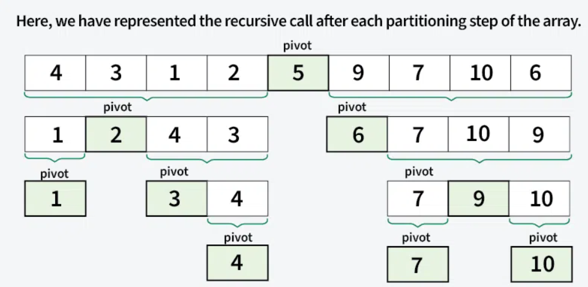

**Pilihan Pivot**

Ada banyak pilihan berbeda untuk memilih pivot.

- Selalu pilih elemen pertama (atau terakhir) sebagai pivot . Implementasi di bawah ini memilih elemen terakhir sebagai pivot. Masalah dengan pendekatan ini adalah akan berakhir pada kasus terburuk ketika array sudah terurut.
- Pilih elemen secara acak sebagai pivot . Ini adalah pendekatan yang lebih disukai karena tidak memiliki pola di mana kasus terburuk terjadi.
- Memilih elemen median sebagai pivot. Ini adalah pendekatan ideal dalam hal kompleksitas waktu karena kita dapat menemukan median dalam waktu linier dan fungsi partisi akan selalu membagi array input menjadi dua bagian. Namun, rata-rata membutuhkan waktu lebih lama karena pencarian median memiliki konstanta yang tinggi.

**Algoritma Partisi** Proses kunci dalam quickSort adalah partisi(). Ada tiga algoritma umum untuk partisi. Semua algoritma ini memiliki kompleksitas waktu O(n).

1. Partisi Sederhana : Di sini kita membuat salinan array. Pertama-tama kita masukkan semua elemen yang lebih kecil, lalu semua elemen yang lebih besar. Terakhir, kita salin array sementara kembali ke array asli. Ini membutuhkan ruang tambahan O(n).
2. Partisi Lomuto : Kami menggunakan partisi ini dalam artikel ini. Ini adalah algoritma sederhana, kita melacak indeks elemen yang lebih kecil dan terus melakukan pertukaran. Kami menggunakannya di sini dalam artikel ini karena kesederhanaannya.
3. Partisi Hoare : Ini adalah yang tercepat dari semuanya. Di sini kita menelusuri array dari kedua sisi dan terus menukar elemen yang lebih besar di sebelah kiri dengan elemen yang lebih kecil di sebelah kanan selama array belum dipartisi. Silakan lihat perbandingan Hoare vs Lomuto untuk detailnya.

### ***Cara Kerja Algoritma Partisi Lomuto Beserta Ilustrasinya**

- Logikanya sederhana, kita mulai dari elemen paling kiri dan melacak indeks elemen yang lebih kecil (atau sama) sebagai i . Saat menelusuri, jika kita menemukan elemen yang lebih kecil, kita menukar elemen saat ini dengan arr[i] . Jika tidak, kita mengabaikan elemen saat ini.

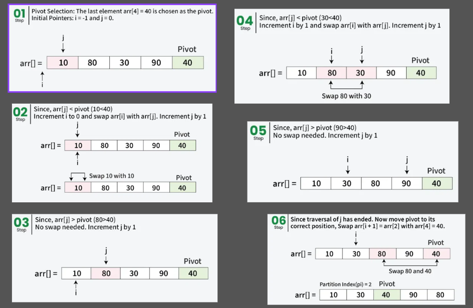

**Ilustrasi Algoritma QuickSort**

Pada langkah sebelumnya, kita telah melihat bagaimana proses partisi mengatur ulang array berdasarkan pivot yang dipilih . Selanjutnya, kita menerapkan metode yang sama secara rekursif pada sub-array yang lebih kecil di sebelah kiri dan kanan pivot. Setiap kali, kita memilih pivot baru dan mempartisi array lagi. Proses ini berlanjut hingga hanya tersisa satu elemen, yang selalu terurut. Setelah setiap elemen berada pada posisi yang benar, seluruh array akan terurut.

Gambar di bawah ini mengilustrasikan bagaimana metode rekursif memanggil sub-array yang lebih kecil di sebelah kiri dan kanan pivot :

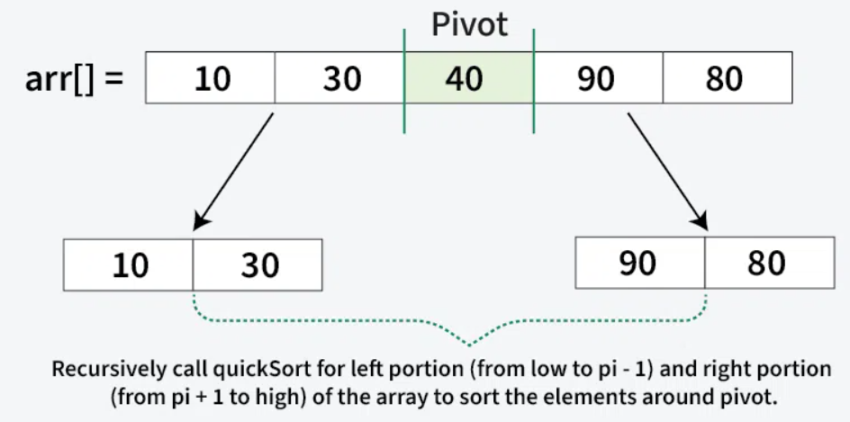

```python
# partition function
def partition(arr, low, high):

    # choose the pivot
    pivot = arr[high]

    # index of smaller element and indicates
    # the right position of pivot found so far
    i = low - 1

    # traverse arr[low..high] and move all smaller
    # elements to the left side. Elements from low to
    # i are smaller after every iteration
    for j in range(low, high):
        if arr[j] < pivot:
            i += 1
            swap(arr, i, j)

    # move pivot after smaller elements and
    # return its position
    swap(arr, i + 1, high)
    return i + 1

# swap function
def swap(arr, i, j):
    arr[i], arr[j] = arr[j], arr[i]

# the QuickSort function implementation
def quickSort(arr, low, high):
    if low < high:

        # pi is the partition return index of pivot
        pi = partition(arr, low, high)

        # recursion calls for smaller elements
        # and greater or equals elements
        quickSort(arr, low, pi - 1)
        quickSort(arr, pi + 1, high)

if __name__ == "__main__":
    arr = [10, 7, 8, 9, 1, 5]
    n = len(arr)

    quickSort(arr, 0, n - 1)

    for val in arr:
        print(val, end=" ")
```

**Analisis Kompleksitas Quick Sort**

**Kompleksitas Waktu:**

- Kasus Terbaik: (Ω(n log n)), Terjadi ketika elemen pivot membagi array menjadi dua bagian yang sama.
- Kasus Rata-Rata (θ(n log n)), Secara rata-rata, pivot membagi array menjadi dua bagian, tetapi tidak selalu sama.
- Kasus Terburuk: (O(n²)), Terjadi ketika elemen terkecil atau terbesar selalu dipilih sebagai pivot (misalnya, array yang sudah diurutkan).

**Ruang Tambahan:**

- Skenario terburuk: O(n) karena partisi yang tidak seimbang menyebabkan pohon rekursi miring yang membutuhkan tumpukan panggilan berukuran O(n).
- Skenario terbaik: O(log n) sebagai hasil dari partisi seimbang yang menghasilkan pohon rekursi seimbang dengan tumpukan panggilan berukuran O(log n).

**Keunggulan Quick Sort**

- Ini adalah algoritma bagi-dan-taklukkan yang mempermudah penyelesaian masalah.
- Metode ini efisien pada kumpulan data yang besar.
- Sistem ini memiliki biaya operasional yang rendah, karena hanya membutuhkan sedikit memori untuk berfungsi.
- Metode ini ramah terhadap cache karena kita bekerja pada array yang sama untuk pengurutan dan tidak menyalin data ke array bantu mana pun.
- Algoritma serbaguna tercepat untuk data besar ketika stabilitas tidak diperlukan.
- Algoritma ini bersifat rekursif ekor , sehingga semua optimasi panggilan ekor dapat dilakukan.

**Kekurangan dari Quick Sort**

- Kompleksitas waktu terburuknya adalah O(n² ) , yang terjadi ketika pivot dipilih dengan buruk.
- Ini bukan pilihan yang baik untuk kumpulan data kecil.
- Ini bukan pengurutan stabil, artinya jika dua elemen memiliki kunci yang sama, urutan relatifnya tidak akan dipertahankan dalam output yang diurutkan dalam kasus pengurutan cepat, karena di sini kita menukar elemen sesuai dengan posisi pivot (tanpa mempertimbangkan posisi aslinya).

**Aplikasi Quick Sort**

- Mengurutkan dataset besar secara efisien di dalam memori.
- Digunakan dalam fungsi pengurutan pustaka (seperti C++ std::sort dan Java Arrays.sort untuk tipe data primitif).
- Mengatur catatan dalam basis data untuk pencarian yang lebih cepat.
- Langkah pra-pemrosesan dalam algoritma yang membutuhkan input yang sudah diurutkan (misalnya, pencarian biner, teknik dua-pointer).
- Mencari elemen terkecil/terbesar ke-k menggunakan Quickselect (varian dari quicksort).
- Mengurutkan array objek berdasarkan beberapa kunci (komparator kustom).
- Algoritma kompresi data (seperti pra-pemrosesan pengkodean Huffman).
- Grafik dan geometri komputasional (misalnya, algoritma convex hull).

### **Penerapan dan penggunaan Quicksort**

Quicksort : Quick sort adalah algoritma Divide Conquer dan algoritma pengurutan tercepat . Dalam quick sort, ia membuat dua array kosong untuk menampung elemen yang lebih kecil dari elemen pivot dan elemen yang lebih besar dari elemen pivot, kemudian secara rekursif mengurutkan sub-array tersebut. Ada banyak versi Quicksort yang memilih pivot dengan cara yang berbeda:

- Selalu pilih elemen pertama sebagai poros.
- Selalu pilih elemen terakhir sebagai pivot.
- Pilih elemen secara acak sebagai pivot.
- Pilih median sebagai titik tumpu.

**Prinsip kerja algoritma Quicksort dijelaskan di bawah ini:**

- Pilih elemen sebagai pivot .
- Pisahkan array menjadi 3 bagian: dengan mengikuti aturan yang diberikan di bawah ini:
  - Bagian pertama: Semua elemen di bagian ini harus lebih kecil dari elemen pivot.
  - Bagian kedua: Elemen tunggal yaitu elemen poros.
  - Bagian ketiga: Semua elemen di bagian ini harus lebih besar dari atau sama dengan elemen pivot. Kemudian, menerapkan algoritma ini pada bagian pertama dan ketiga (secara rekursif).

**Berikut adalah kegunaan dan aplikasi Quicksort dalam praktik nyata:**

- Komputasi Komersial digunakan di berbagai organisasi pemerintah dan swasta untuk tujuan pengurutan berbagai data seperti pengurutan file berdasarkan nama/tanggal/harga, pengurutan siswa berdasarkan nomor absen, pengurutan profil akun berdasarkan ID yang diberikan, dll., karena ini adalah algoritma tujuan umum tercepat untuk data dalam jumlah besar.
- Karena kedua sub-array dapat diproses secara independen, kita dapat dengan mudah melakukan pemrosesan paralel.
- Algoritma ini digunakan hampir di semua tempat di mana pengurutan stabil tidak diperlukan. Untuk stabilitas, Merge Sort biasanya digunakan.
- Quicksort adalah algoritma yang ramah terhadap cache karena memiliki lokalitas referensi yang baik ketika digunakan untuk array.
- Algoritma ini bersifat rekursif ekor , sehingga semua optimasi panggilan ekor dapat dilakukan.
- Ini adalah algoritma pengurutan in-place yang tidak memerlukan memori penyimpanan tambahan untuk menyimpan elemen (tidak seperti Merge Sort yang membutuhkan ruang tambahan untuk penggabungan).
- Dalam komputasi numerik dan penelitian ilmiah, untuk akurasi perhitungan, sebagian besar algoritma yang dikembangkan secara efisien menggunakan antrian prioritas dan pengurutan cepat (quick sort) digunakan untuk pengurutan.
- Varian Quicksort digunakan untuk memisahkan elemen terkecil atau terbesar ke-K .
- Ini digunakan untuk mengimplementasikan metode tipe primitif.
- Jika data diurutkan, maka pencarian informasi menjadi mudah dan efisien menggunakan algoritma seperti pencarian biner.
- QuickSort biasanya diimplementasikan dalam fungsi pustaka bahasa pemrograman untuk mengurutkan array. Misalnya, qsort di C , Arrays.sort di Java , sort di C++ menggunakan Pengurutan Hibrida di mana QuickSort adalah pengurutan utama.

# **LATIHAN CODE**

**Soal 1: Implementasi Quick Sort dengan Pivot Elemen Terakhir Instruksi: Buatlah fungsi partition dan quick_sort yang memilih elemen terakhir sebagai pivot untuk mengurutkan daftar angka.**

```python
def partition(arr, low, high):
    pivot = arr[high]
    i = low - 1
    for j in range(low, high):
        if arr[j] <= pivot:
            i += 1
            arr[i], arr[j] = arr[j], arr[i]
    arr[i+1], arr[high] = arr[high], arr[i+1]
    return i + 1

def quick_sort(arr, low, high):
    if low < high:
        pi = partition(arr, low, high)
        quick_sort(arr, low, pi - 1)
        quick_sort(arr, pi + 1, high)
    return arr

data = [10, 7, 8, 9, 1, 5]
print(f"Data terurut: {quick_sort(data, 0, len(data)-1)}")
```

**Soal 2: Quick Sort dengan Pivot Tengah (Optimasi) Instruksi: Gunakan elemen di posisi tengah sebagai pivot untuk mengurangi kemungkinan terjadinya worst-case O(n^2).**

```python
def quick_sort_mid(arr):
    if len(arr) <= 1: return arr
    pivot = arr[len(arr) // 2]
    left = [x for x in arr if x < pivot]
    middle = [x for x in arr if x == pivot]
    right = [x for x in arr if x > pivot]
    return quick_sort_mid(left) + middle + quick_sort_mid(right)

data = [3, 6, 8, 10, 1, 2, 1]
print(f"Hasil: {quick_sort_mid(data)}")
```

**Soal 3: Visualisasi Proses Partisi Instruksi: Tampilkan setiap langkah pertukaran yang dilakukan saat proses partisi agar penguji bisa melihat logika i dan j bergeser.**

```python
def partition_log(arr, low, high):
    pivot = arr[high]
    print(f"Pivot terpilih: {pivot}")
    i = low - 1
    for j in range(low, high):
        if arr[j] <= pivot:
            i += 1
            arr[i], arr[j] = arr[j], arr[i]
            print(f"Tukar {arr[i]} dan {arr[j]}: {arr}")
    arr[i+1], arr[high] = arr[high], arr[i+1]
    return i + 1

data = [2, 8, 7, 1, 3, 5]
partition_log(data, 0, len(data)-1)
```

**Soal 4: Quick Sort Descending Instruksi: Ubah logika pembanding pada bagian partisi agar urutan hasil akhirnya menjadi dari terbesar ke terkecil.**

```python
def partition_desc(arr, low, high):
    pivot = arr[high]
    i = low - 1
    for j in range(low, high):
        if arr[j] >= pivot: # Ubah ke >=
            i += 1
            arr[i], arr[j] = arr[j], arr[i]
    arr[i+1], arr[high] = arr[high], arr[i+1]
    return i + 1
# (Panggil fungsi quick_sort yang sama dengan sebelumnya)
```

**Soal 5: Menghitung Total Pertukaran (Swaps) Instruksi: Buatlah variabel global total_swaps untuk menghitung berapa kali penukaran elemen terjadi dalam seluruh proses Quick Sort.**

```python
total_swaps = 0
def partition_count(arr, low, high):
    global total_swaps
    pivot = arr[high]
    i = low - 1
    for j in range(low, high):
        if arr[j] <= pivot:
            i += 1
            arr[i], arr[j] = arr[j], arr[i]
            total_swaps += 1
    arr[i+1], arr[high] = arr[high], arr[i+1]
    total_swaps += 1
    return i + 1
```

**Soal 6: Quick Sort untuk List String Instruksi: Urutkan daftar kata berdasarkan panjang string-nya, jika panjang sama urutkan berdasarkan abjad.**

```python
def quick_sort_str(arr):
    if len(arr) <= 1: return arr
    pivot = arr[len(arr)//2]
    # Kriteria: panjang string, lalu alfabet
    left = [x for x in arr if (len(x), x) < (len(pivot), pivot)]
    mid = [x for x in arr if (len(x), x) == (len(pivot), pivot)]
    right = [x for x in arr if (len(x), x) > (len(pivot), pivot)]
    return quick_sort_str(left) + mid + quick_sort_str(right)

print(quick_sort_str(["Zaka", "Budi", "Aisyah", "Ali"]))
```

**Soal 7: Randomized Quick Sort Instruksi: Pilih pivot secara acak dari rentang array untuk menghindari skenario terburuk.**

```python
import random
def randomized_partition(arr, low, high):
    rand_pivot = random.randint(low, high)
    arr[rand_pivot], arr[high] = arr[high], arr[rand_pivot]
    return partition(arr, low, high) # partition dari Soal 1
```

```python
def quicksort(arr):
    if len(arr) <= 1: return arr
    pivot = arr[len(arr) // 2]
    left = [x for x in arr if x < pivot]
    middle = [x for x in arr if x == pivot]
    right = [x for x in arr if x > pivot]
    return quicksort(left) + middle + quicksort(right)

# Zaka, ini cara paling Pythonic dan mudah dijelaskan saat demo!
data = [12, 4, 5, 6, 7, 3, 1, 15]
print(f"Data: {quicksort(data)}")
```